# Pilot Analysis

Mara Rehmer

6 8 2021

## Loading and inspecting the data

First of all we load the data set and take a look at it.

```
## Rows: 3,111
## Columns: 27
## $ submission_id <dbl> 2404, 2404, 2404, 2404, 2404, 2404, 2404, 2404, 2404, 24~
## $ QUD           <lgl> NA, NA, NA, NA, NA, NA, NA, NA, NA, NA, NA, NA, NA, NA, ~
## $ RT            <dbl> 3531, 2055, 1897, 1790, 1809, 3090, 1945, 1850, 1874, 17~
## $ a             <chr> "links/left", "links/left", NA, "links/left", "links/lef~
## $ age           <dbl> 22, 22, 22, 22, 22, 22, 22, 22, 22, 22, 22, 22, 22, 22, ~
## $ comments      <chr> NA, NA, NA, NA, NA, NA, NA, NA, NA, NA, NA, NA, NA, NA, ~
## $ correctness   <chr> "correct", "incorrect", "correct", "correct", "incorrect~
## $ d             <chr> "rechts/right", "rechts/right", NA, "rechts/right", "rec~
## $ education     <chr> "Graduated High School", "Graduated High School", "Gradu~
## $ endTime       <dbl> 1.627734e+12, 1.627734e+12, 1.627734e+12, 1.627734e+12, ~
## $ expected      <chr> "rechts/right", "links/left", "oben/up", "rechts/right",~
## $ experiment_id <dbl> 271, 271, 271, 271, 271, 271, 271, 271, 271, 271, 271, 2~
## $ gender        <chr> "female", "female", "female", "female", "female", "femal~
## $ key1          <chr> "a", "a", "w", "a", "a", "a", "w", "w", "w", "a", "w", "~
## $ key2          <chr> "d", "d", "s", "d", "d", "d", "s", "s", "s", "d", "s", "~
## $ key_pressed   <chr> "d", "d", "w", "d", "a", "a", "w", "s", "s", "a", "s", "~
## $ languages     <chr> "German", "German", "German", "German", "German", "Germa~
## $ picture       <chr> "data:…
## $ question      <chr> "Welche Matrix wurde zufällig erzeugt? / Which matrix is~
## $ s             <chr> NA, NA, "unten/down", NA, NA, NA, "unten/down", "unten/d~
## $ startDate     <chr> "Sat Jul 31 2021 14:06:38 GMT+0200 (Mitteleuropäische So~
## $ startTime     <dbl> 1.627733e+12, 1.627733e+12, 1.627733e+12, 1.627733e+12, ~
## $ switch_rate   <dbl> 0.16, 0.06, 0.66, 0.66, 0.14, 0.24, 0.72, 0.14, 0.88, 0.~
## $ timeSpent     <dbl> 20.30787, 20.30787, 20.30787, 20.30787, 20.30787, 20.307~
## $ trial_name    <chr> "identification", "identification", "identification", "i~
## $ trial_number  <dbl> 1, 2, 3, 4, 5, 6, 7, 8, 9, 10, 11, 12, 13, 14, 15, 16, 1~
## $ w             <chr> NA, NA, "oben/up", NA, NA, NA, "oben/up", "oben/up", "ob~
```

Now, we have to exclude test trials. These were the first one after which we shared the link with our pilot participants. Then we had directly two problems with uploading the data to the server, which is why then two of us tried it out again. Meanwhile one set of data points was submitted. This is why we filter out the three trials with submission id 2391, 2395 and 2396.

### Participants

A total of 4 participants took part in an online version of a Perception of Randomness task. There were 2 male, 2 female and 0 other participants, with ages ranging from 20 to 25.

### General properties and cleaning

First we have a look at the comments which were answers to our question whether the participant had any idea what this experiment is about.

```
## [1] NA
## [2] "Das high-level Konzept was ihr untersuchen wollt, keine Ahnung. Aber wahrscheinlich werdet ihr (unter anderem) auswerten, wie gut die Accuracy war bei bestimmter Schwierigkeit der Boundaries zwischen den 2 Grenzen :D"
## [3] "Mustererkennung"
```

The second answer is going into the right direction, because we are actually going to analyze the accuracy or proportion of correct answers for all different levels of switch rate (more on this below). We can see that none of the participants wrote down “randomness”.

We check general properties of the data, like a summary of the reaction time (`RT`) and the overall time spent on the experiment (`timeSpent`).

```
## [1] "Summary of RT"
```

```
##    Min. 1st Qu.  Median    Mean 3rd Qu.    Max.
##    1509    1752    1797    2101    1889   93123
```

```
## [1] "Summary of time spent"
```

```
##    Min. 1st Qu.  Median    Mean 3rd Qu.    Max.
##   20.31   20.85   21.48   21.98   22.60   24.65
```

The overall time spent on the experiment looks fine, but the maximal `RT` is quite high.

We will clean the data by only selecting the columns that are relevant for us and get rid of outliers. First of all we select the columns that are relevant for our analysis:  
`submission_id`: individual identifier of each subject  
`trial_name`: which we rename to `condition` which is either identification or discrimination  
`trial_number`: number of trial (used for plotting the outliers)  
`switch_rate`: ordered factor ranging from 0 to 1 in steps of 0.02 indicating the generating process of the stimuli (named `swr`)  
`correctness`: whether the answer of the participant was correct  
`RT`: reaction time in ms for each trial (base line is 1500 ms from showing the stimulus)  
`timeSpent`: overall time spent

We choose to exclude individual trials with a reaction time (`RT`) bigger than 8000 ms, because we cannot be sure that participants recall the stimulus correctly after this time and just press any of the keys to continue to the next trial. We don’t exclude “too fast” reaction times because answers can only be entered after the stimulus was shown for 1500 ms. We make `swr` (switch rate) an unordered factor and have a look at which data points do not fulfill our time limits and therefore qualify as outliers.

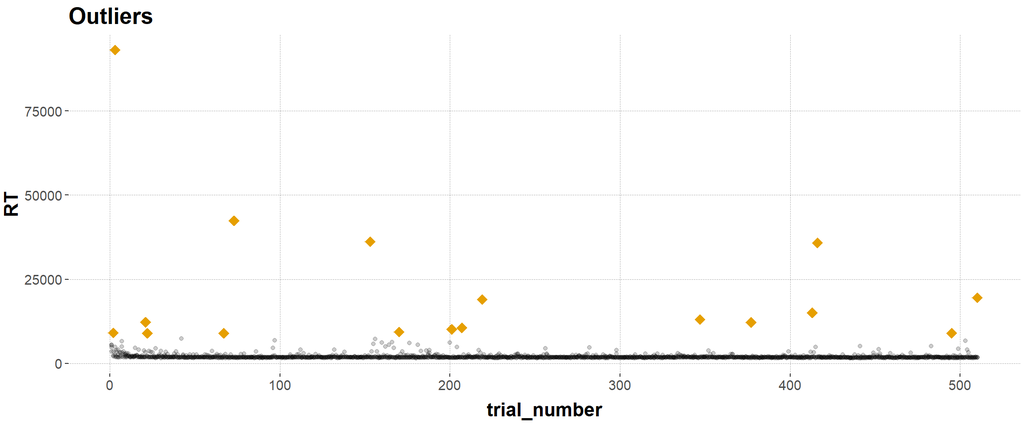

We excluded 17 trials for having too long reaction times.

### Summary statistics

We will have a look at some summary statistics like the mean accuracy for both conditions.

```
## # A tibble: 2 x 2
##   condition      mean_accuracy
##   <chr>                  <dbl>
## 1 discrimination         0.132
## 2 identification         0.500
```

Looking at the mean accuracy of both conditions we see that something must have went wrong. (We find out that we mixed up correct and incorrect in the experiment coding, the last pilot submission was done when this was already fixed). Now we fix this mistake so we do not lose the data.

We look at mean accuracy for each condition again:

```
## # A tibble: 2 x 2
##   condition      mean_accuracy
##   <chr>                  <dbl>
## 1 discrimination         0.868
## 2 identification         0.823
```

These results seem to be more realistic.

We also have a look at each participants individual accuracy.

```
## # A tibble: 4 x 3
##   submission_id individual_accuracy condition
##           <dbl>               <dbl> <chr>
## 1          2394               0.823 identification
## 2          2398               0.832 discrimination
## 3          2400               0.902 discrimination
## 4          2404               0.824 identification
```

While three of the participants have very similar values, the fourth (submission_id 2400) was clearly better at the task. This is why the over all accuracy is higher in the discrimination condition.

## Hypothesis

The hypothesis of the original paper states

> The probability of correctly identifying stimuli from R [random source] and N [non-random source] coincides with the ease of distinguishing between the two sources.

Or in other words: The proportion of correct answers for both conditions is not significantly different.

## Analysis

It is a 2x51 mixed factorial design, where the first factor is `condition` with two values *discrimination* or *identification*. The second factor is `switch rate` which has 51 levels (from 0 to 1 in steps of 0.02). Each participant contributes data points for only one condition (between-subjects) but multiple data points (ideally 10) for each switch rate (within-subject, repeated measures).

We use a Bayesian Logistic Regression Model which models the `correctness` as dependent variable in terms of `condition` and `switch_rate` as independent variables. We choose this as a measure of proportion of correct responses in each condition and switch rate instead of a beforehand calculated summary statistic like accuracy which was used in the original paper. We choose not to average over all participants and switch rates in the two condition because this summary of the data will lead our model to underestimate the variance in the data.

```
##  Family: bernoulli
##   Links: mu = logit
## Formula: correctness ~ condition * swr + (1 | submission_id)
##    Data: clean_data %>% mutate(correctness = correctness == (Number of observations: 2023)
## Samples: 4 chains, each with iter = 5000; warmup = 2500; thin = 1;
##          total post-warmup samples = 10000
##
## Group-Level Effects:
## ~submission_id (Number of levels: 4)
##               Estimate Est.Error l-95% CI u-95% CI Rhat Bulk_ESS Tail_ESS
## sd(Intercept)     0.82      0.72     0.18     2.78 1.00     3848     4441
##
## Population-Level Effects:
##                                 Estimate Est.Error l-95% CI u-95% CI Rhat
## Intercept                           2.46      0.74     0.78     3.76 1.00
## conditionidentification             0.04      0.83    -1.67     1.66 1.00
## swr0.02                             0.80      1.06    -0.94     3.25 1.00
## swr0.04                             0.01      0.80    -1.41     1.76 1.00
## swr0.06                             1.87      1.64    -0.34     6.03 1.00
## swr0.08                             6.84     11.51     0.04    36.38 1.00
## swr0.1                              7.00     11.31     0.08    39.66 1.00
## swr0.12                             0.85      1.08    -0.89     3.31 1.00
## swr0.14                             1.71      2.05    -0.52     6.39 1.00
## swr0.16                             0.08      0.81    -1.37     1.84 1.00
## swr0.18                             7.00     12.01     0.06    37.10 1.00
## swr0.2                              0.84      1.04    -0.86     3.26 1.00
## swr0.22                             0.84      1.06    -0.88     3.24 1.00
## swr0.24                             0.08      0.80    -1.37     1.81 1.00
## swr0.26                            -0.41      0.70    -1.71     1.01 1.00
## swr0.28                            -0.13      0.72    -1.45     1.39 1.00
## swr0.3                              0.43      0.86    -1.09     2.33 1.00
## swr0.32                            -0.59      0.65    -1.83     0.72 1.00
## swr0.34                            -0.13      0.72    -1.45     1.42 1.00
## swr0.36                            -0.63      0.64    -1.84     0.68 1.00
## swr0.38                            -0.23      0.74    -1.58     1.33 1.00
## swr0.4                             -1.11      0.61    -2.29     0.12 1.00
## swr0.42                            -2.09      0.56    -3.19    -0.98 1.00
## swr0.44                            -2.77      0.56    -3.87    -1.71 1.00
## swr0.46                            -2.22      0.54    -3.27    -1.17 1.00
## swr0.48                            -2.35      0.55    -3.43    -1.28 1.00
```

[output cut: 168 more lines]

```
## conditionidentification:swr0.8      2020     1484
## conditionidentification:swr0.82     1992     1461
## conditionidentification:swr0.84      973      318
## conditionidentification:swr0.86     2725      938
## conditionidentification:swr0.88     1901     1140
## conditionidentification:swr0.9       615      182
## conditionidentification:swr0.92     1073      400
## conditionidentification:swr0.94     2002     1136
## conditionidentification:swr0.96     2227      689
## conditionidentification:swr0.98     4647     2095
## conditionidentification:swr1       11621     7305
##
## Samples were drawn using sampling(NUTS). For each parameter, Bulk_ESS
## and Tail_ESS are effective sample size measures, and Rhat is the potential
## scale reduction factor on split chains (at convergence, Rhat = 1).
```

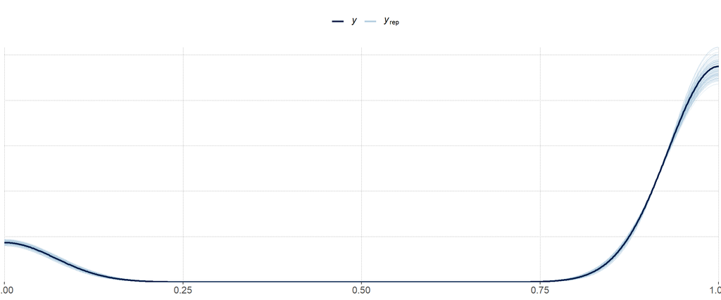

Looking at the `pp_check` we can see that the model neatly captures the nature of our data.

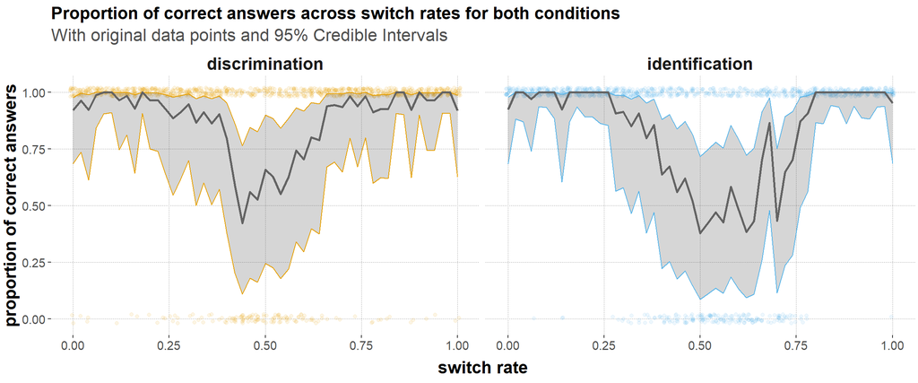

In this plot we can see that there is a lot of uncertainty around the mean estimates for each switch rate (in both conditions). We can also see that for low and high switch rates (from 0 to 0.25 and from 0.75 to 1) there is a little bit more variability in the discrimination condition. This could be due to lack of concentration. Another visible difference is that the graph in the discrimination condition has a narrower region of less correct answers.

### Conclusion

Since we have only little data, we don’t draw any conclusion regarding our hypothesis.